# NYC Yellow Taxi — Trip Quality Analysis 2018–2022

### Stratified Sample · ~289,000 trips (post-cleaning) · Polars + DuckDB

## Management Summary

**What this data is:** ~305,000 NYC TLC Yellow Taxi trips sampled equally across 2018–2022 (≈60k per year), plus a partial January 2023 slice. Sampling equalises trip count **per year**, so this cannot measure absolute ridership volumes. It measures how the *shape* of a typical trip changed — fare levels, payment behaviour, speed, and trip-type mix.

### Key Findings and Operational Implications

**2. Congestion surcharge: from zero to structural** (0% → 93%+ of trips by 2021). Riders absorbed the $2.50 charge without visible defection over the sample period.  
*→ It is permanent baseline, not a recoverable surcharge. Competitive comparisons with TNCs must include it; omitting it overstates the price gap.*

**3. Cash near-halved** (30% → 20% of trips). Lower cash-handling costs for operators, but the remaining 20% likely skews toward unbanked, tourist, or privacy-motivated riders whose trip profile differs from card payers.  
*→ Eliminating cash would be a non-trivial access policy decision, not a clean operational simplification.*

**4. In-app tip defaults drove a 5pp rate increase** (22% → 27% on card trips). The mechanism is prompt design — the 20–25% bucket collapsed as app presets shifted upward — not greater rider generosity. This delivered ~$0.74/trip more to drivers without any fare change.  
*→ An equivalent income gain via base fare hike would require a ~5% rate increase, which carries demand-side risk. Prompt design does not.*

**5. 2020 speed anomaly: +16%** (11.3 → 13.1 mph average). Emptied streets moved trips above the TLC meter's 12 mph time-rate threshold, lowering fare per mile even as trip cost fell overall. The improvement was largest at rush hours, confirming a structural congestion collapse rather than a trip-type shift.  
*→ Fleet capacity models should treat 2020-level speeds as a low-demand ceiling, not a recoverable norm.*

### Sampling Design Caveat

Each year contributes ~60,000 trips. Cross-year comparisons of *rates* (fare/mile, tip %, payment mix) are valid. Comparisons of *absolute volume* are **not** — 2020 had far fewer actual rides, but the sample forces parity. Within-year monthly distributions are preserved; the COVID dip is confirmed visible inside the 2020 slice (§ 6).

*Full methodology and charts follow. Analysis excludes the partial January 2023 slice.*

## 1. Setup & Ingestion

The CSV is read once with **Polars** (zero-copy columnar frame), then queried throughout via **DuckDB** — which resolves the Python variable name directly, giving us SQL over a Polars frame with no serialisation overhead.

`infer_schema_length=100_000` is required because `airport_fee` and `congestion_surcharge` are empty in the first several thousand rows (those fees did not exist in 2018), causing the default 100-row inferrer to mis-type them.

```python
import polars as pl
import duckdb
import matplotlib.pyplot as plt
import matplotlib.ticker as mtick
import numpy as np
import pandas as pd
import warnings

warnings.filterwarnings('ignore')

# ── colour palette ────────────────────────────────────────────────────────────
BLUE   = '#3D7EAA'
GREEN  = '#4CAF78'
ORANGE = '#E8833A'
RED    = '#D94F3D'
PURPLE = '#7B5EA7'
GREY   = '#AAAAAA'

plt.rcParams.update({
    'figure.dpi':        130,
    'font.size':         11,
    'axes.titlesize':    13,
    'axes.labelsize':    11,
    'axes.spines.top':   False,
    'axes.spines.right': False,
    'axes.grid':         True,
    'axes.grid.axis':    'y',
    'grid.alpha':        0.3,
    'grid.linestyle':    '--',
})

# Resolve data path whether CWD is project root (jupyter lab) or notebooks/ (nbconvert)
from pathlib import Path
_data = Path('data/Yellow_Taxi_Assignment.csv')
if not _data.exists():
    _data = Path('../data/Yellow_Taxi_Assignment.csv')
CSV_PATH = _data
trips_raw = pl.read_csv(CSV_PATH, infer_schema_length=100_000, try_parse_dates=True)
print(f'Loaded  {trips_raw.shape[0]:,} rows × {trips_raw.shape[1]} columns')
trips_raw.head(3)
```

```
Loaded  304,978 rows × 19 columns
```

shape: (3, 19)

| VendorID i64 | tpep_pickup_datetime datetime[μs] | tpep_dropoff_datetime datetime[μs] | passenger_count f64 | trip_distance f64 | RatecodeID f64 | store_and_fwd_flag str | PULocationID i64 | DOLocationID i64 | payment_type i64 | fare_amount f64 | extra f64 | mta_tax f64 | tip_amount f64 | tolls_amount f64 | improvement_surcharge f64 | total_amount f64 | congestion_surcharge f64 | airport_fee str |
| --- | --- | --- | --- | --- | --- | --- | --- | --- | --- | --- | --- | --- | --- | --- | --- | --- | --- | --- |
| 2 | 2018-01-01 12:02:01 | 2018-01-01 12:04:05 | 1.0 | 0.53 | 1.0 | "N" | 142 | 163 | 1 | 3.5 | 0.0 | 0.5 | 1.29 | 0.0 | 0.3 | 5.59 | null | null |
| 2 | 2018-01-01 12:26:48 | 2018-01-01 12:31:29 | 1.0 | 1.05 | 1.0 | "N" | 140 | 236 | 1 | 6.0 | 0.0 | 0.5 | 1.02 | 0.0 | 0.3 | 7.82 | null | null |
| 2 | 2018-01-01 01:28:34 | 2018-01-01 01:39:38 | 4.0 | 1.83 | 1.0 | "N" | 211 | 158 | 1 | 9.5 | 0.5 | 0.5 | 1.62 | 0.0 | 0.3 | 12.42 | null | null |

## 2. Data Quality Audit & Cleaning

### Null landscape

Fourteen of 19 columns are fully populated. The three structurally incomplete columns, and a fourth that carries negative values, are documented below before any rows are removed. The audit code cell that follows produces all counts as queryable output.

#### Structural null block — 3.12% of rows

The 9,513 rows where `payment_type = 0` are *simultaneously* null in `passenger_count`, `RatecodeID`, and `store_and_fwd_flag`. These are not independent missing values — they are the same incomplete dispatch records. The `payment_type != 0` drop rule clears the entire block in one step; no separate null imputation is needed for those three columns.

#### Fee columns — structural absence, not missing data

| Column | Null % | Root cause | Decision |
| --- | --- | --- | --- |
| `airport_fee` | 65.2% | `VARCHAR`; fee introduced ~2022; pre-2022 rows are empty string | Cast to `DOUBLE`; null / empty → 0; 55 rows of `"-1.25"` (refund artefacts) floored to 0 via `GREATEST(..., 0)` |
| `congestion_surcharge` | 23.8% | Fee did not exist before Feb 2019; also exempt outer-borough trips | Null → 0 (structural absence, not missing data) |
| `passenger_count` | 3.12% | Same block as `payment_type = 0` records | Block dropped; no imputation required |

### Validity rules — rows dropped outright

[output not shown]

### Negative ancillary charges — retained with documentation

Six fee columns contain small numbers of negative values that **pass** the validity rules (because `total_amount` is still positive on those rows):

| Column | Negative rows | Typical value | Interpretation |
| --- | --- | --- | --- |
| `improvement_surcharge` | 1,160 (0.38%) | −$0.30 | Voided / refunded charge |
| `mta_tax` | 1,123 (0.37%) | −$0.50 | Voided / refunded charge |
| `congestion_surcharge` | 891 (0.29%) | −$2.50 | Voided / refunded charge |
| `extra` | 541 (0.18%) | −$0.50 | Voided rush-hour surcharge |
| `tolls_amount` | 38 (0.01%) | varies | Refund |
| `tip_amount` | 14 (< 0.01%) | varies | Tip reversal |

### Undocumented categoricals

| Column | Undocumented value(s) | Count | Treatment |
| --- | --- | --- | --- |
| `VendorID` | 4, 5, 6 | 1,024 rows | Retained; excluded from any vendor-specific cut |
| `RatecodeID` | 6 | 1 row | Retained; falls into "Other" trip-type category |
| `store_and_fwd_flag` | Y (documented but rarely flagged) | 3,040 (1.0%) | Y = record held in vehicle memory before upload. Retained; not used in analysis |

```python
# ── 1. Per-column null audit ─────────────────────────────────────────────────
null_audit = duckdb.sql('''
    SELECT col, null_count, total,
           ROUND(100.0 * null_count / total, 2) AS null_pct,
           dtype
    FROM (
        VALUES
          ('airport_fee',           (SELECT COUNT(*) FILTER (WHERE airport_fee IS NULL)           FROM trips_raw), 304978, 'VARCHAR → DOUBLE'),
          ('congestion_surcharge',  (SELECT COUNT(*) FILTER (WHERE congestion_surcharge IS NULL)  FROM trips_raw), 304978, 'DOUBLE'),
          ('passenger_count',       (SELECT COUNT(*) FILTER (WHERE passenger_count IS NULL)       FROM trips_raw), 304978, 'DOUBLE → INT'),
          ('RatecodeID',            (SELECT COUNT(*) FILTER (WHERE RatecodeID IS NULL)            FROM trips_raw), 304978, 'DOUBLE → INT'),
          ('store_and_fwd_flag',    (SELECT COUNT(*) FILTER (WHERE store_and_fwd_flag IS NULL)    FROM trips_raw), 304978, 'VARCHAR'),
          ('fare_amount',           (SELECT COUNT(*) FILTER (WHERE fare_amount IS NULL)           FROM trips_raw), 304978, 'DOUBLE'),
          ('total_amount',          (SELECT COUNT(*) FILTER (WHERE total_amount IS NULL)          FROM trips_raw), 304978, 'DOUBLE'),
          ('tip_amount',            (SELECT COUNT(*) FILTER (WHERE tip_amount IS NULL)            FROM trips_raw), 304978, 'DOUBLE'),
          ('trip_distance',         (SELECT COUNT(*) FILTER (WHERE trip_distance IS NULL)         FROM trips_raw), 304978, 'DOUBLE'),
          ('VendorID',              (SELECT COUNT(*) FILTER (WHERE VendorID IS NULL)              FROM trips_raw), 304978, 'BIGINT'),
          ('tpep_pickup_datetime',  (SELECT COUNT(*) FILTER (WHERE tpep_pickup_datetime IS NULL)  FROM trips_raw), 304978, 'TIMESTAMP'),
          ('tpep_dropoff_datetime', (SELECT COUNT(*) FILTER (WHERE tpep_dropoff_datetime IS NULL) FROM trips_raw), 304978, 'TIMESTAMP')
    ) t(col, null_count, total, dtype)
    ORDER BY null_count DESC
''').pl()

print('── Null audit ──')
display(null_audit)

# ── 2. Negative values in ancillary fee columns ───────────────────────────────
neg_audit = duckdb.sql('''
    SELECT col, neg_count,
           ROUND(100.0 * neg_count / 304978, 3) AS pct_of_raw
    FROM (
        VALUES
          ('improvement_surcharge', (SELECT COUNT(*) FROM trips_raw WHERE improvement_surcharge < 0)),
          ('mta_tax',               (SELECT COUNT(*) FROM trips_raw WHERE mta_tax               < 0)),
          ('congestion_surcharge',  (SELECT COUNT(*) FROM trips_raw WHERE congestion_surcharge  < 0)),
          ('extra',                 (SELECT COUNT(*) FROM trips_raw WHERE extra                 < 0)),
          ('tolls_amount',          (SELECT COUNT(*) FROM trips_raw WHERE tolls_amount          < 0)),
          ('tip_amount',            (SELECT COUNT(*) FROM trips_raw WHERE tip_amount            < 0))
    ) t(col, neg_count)
    ORDER BY neg_count DESC
''').pl()

print('\n── Negative ancillary charges (pass validity filter; retained) ──')
display(neg_audit)

# ── 3. airport_fee raw string values (VARCHAR column) ────────────────────────
fee_vals = duckdb.sql('''
    SELECT COALESCE(airport_fee, 'NULL') AS raw_value,
           COUNT(*) AS n,
           ROUND(100.0 * COUNT(*) / 304978, 2) AS pct
    FROM trips_raw
    GROUP BY airport_fee
    ORDER BY n DESC
''').pl()

print('\n── airport_fee raw values (VARCHAR) ──')
display(fee_vals)

# ── 4. VendorID — confirm undocumented codes ──────────────────────────────────
vendor_vals = duckdb.sql('''
    SELECT VendorID,
           CASE VendorID
               WHEN 1 THEN 'Creative Mobile Technologies'
               WHEN 2 THEN 'VeriFone Inc.'
               ELSE        'Undocumented'
           END AS vendor_name,
           COUNT(*) AS n,
           ROUND(100.0 * COUNT(*) / 304978, 2) AS pct
    FROM trips_raw
    GROUP BY VendorID
    ORDER BY n DESC
''').pl()

print('\n── VendorID values ──')
display(vendor_vals)
```

```
── Null audit ──
```

shape: (12, 5)

| col str | null_count i64 | total i32 | null_pct f64 | dtype str |
| --- | --- | --- | --- | --- |
| "airport_fee" | 198761 | 304978 | 65.17 | "VARCHAR → DOUBLE" |
| "congestion_surcharge" | 72632 | 304978 | 23.82 | "DOUBLE" |
| "passenger_count" | 9513 | 304978 | 3.12 | "DOUBLE → INT" |
| "RatecodeID" | 9513 | 304978 | 3.12 | "DOUBLE → INT" |
| "store_and_fwd_flag" | 9513 | 304978 | 3.12 | "VARCHAR" |
| … | … | … | … | … |
| "tip_amount" | 0 | 304978 | 0.0 | "DOUBLE" |
| "trip_distance" | 0 | 304978 | 0.0 | "DOUBLE" |
| "VendorID" | 0 | 304978 | 0.0 | "BIGINT" |
| "tpep_pickup_datetime" | 0 | 304978 | 0.0 | "TIMESTAMP" |
| "tpep_dropoff_datetime" | 0 | 304978 | 0.0 | "TIMESTAMP" |

```
── Negative ancillary charges (pass validity filter; retained) ──
```

shape: (6, 3)

| col str | neg_count i64 | pct_of_raw f64 |
| --- | --- | --- |
| "improvement_surcharge" | 1160 | 0.38 |
| "mta_tax" | 1123 | 0.368 |
| "congestion_surcharge" | 891 | 0.292 |
| "extra" | 541 | 0.177 |
| "tolls_amount" | 38 | 0.012 |
| "tip_amount" | 14 | 0.005 |

```
── airport_fee raw values (VARCHAR) ──
```

shape: (4, 3)

| raw_value str | n i64 | pct f64 |
| --- | --- | --- |
| "NULL" | 198761 | 65.17 |
| "0.0" | 98815 | 32.4 |
| "1.25" | 7347 | 2.41 |
| "-1.25" | 55 | 0.02 |

```
── VendorID values ──
```

shape: (5, 4)

| VendorID i64 | vendor_name str | n i64 | pct f64 |
| --- | --- | --- | --- |
| 2 | "VeriFone Inc." | 201068 | 65.93 |
| 1 | "Creative Mobile Technologies" | 102886 | 33.74 |
| 6 | "Undocumented" | 521 | 0.17 |
| 4 | "Undocumented" | 500 | 0.16 |
| 5 | "Undocumented" | 3 | 0.0 |

```python
trips_clean = duckdb.sql('''
    WITH casted AS (
        SELECT
            *,
            -- airport_fee is VARCHAR; 55 rows hold "-1.25" (refund artefacts).
            -- GREATEST(..., 0) floors those to 0 after the numeric cast.
            GREATEST(TRY_CAST(airport_fee AS DOUBLE), 0) AS airport_fee_num
        FROM trips_raw
    ),
    filtered AS (
        SELECT * FROM casted
        WHERE  fare_amount                        >  0
           AND total_amount                       >  0
           AND trip_distance                      >  0
           AND trip_distance                      <= 200
           AND tpep_dropoff_datetime              >  tpep_pickup_datetime
           AND ratecodeid                         != 99
           AND payment_type                       != 0
    )
    SELECT
        VendorID                                  AS vendor_id,
        tpep_pickup_datetime                      AS pickup_dt,
        tpep_dropoff_datetime                     AS dropoff_dt,
        COALESCE(passenger_count, 1)::INT         AS passenger_count,
        trip_distance,
        ratecodeid::INT                           AS rate_code,
        store_and_fwd_flag,
        PULocationID                              AS pu_location_id,
        DOLocationID                              AS do_location_id,
        payment_type::INT                         AS payment_type,
        fare_amount,
        extra,
        mta_tax,
        tip_amount,
        tolls_amount,
        improvement_surcharge,
        total_amount,
        COALESCE(congestion_surcharge, 0)         AS congestion_surcharge,
        COALESCE(airport_fee_num,      0)         AS airport_fee
    FROM filtered
''').pl()

n_raw   = trips_raw.shape[0]
n_clean = trips_clean.shape[0]
n_drop  = n_raw - n_clean
print(f'Raw rows  : {n_raw:,}')
print(f'Dropped   : {n_drop:,}  ({100*n_drop/n_raw:.1f}%)')
print(f'Clean rows: {n_clean:,}')
```

```
Raw rows  : 304,978
Dropped   : 14,433  (4.7%)
Clean rows: 290,545
```

```python
duckdb.sql('''
    SELECT rule, violations,
           ROUND(100.0 * violations / (SELECT COUNT(*) FROM trips_raw), 2) AS pct_of_raw
    FROM (
        VALUES
          ('Negative / zero fare',         (SELECT COUNT(*) FROM trips_raw WHERE fare_amount  <= 0)),
          ('Negative / zero total',         (SELECT COUNT(*) FROM trips_raw WHERE total_amount <= 0)),
          ('Non-positive distance',         (SELECT COUNT(*) FROM trips_raw WHERE trip_distance <= 0)),
          ('Distance > 200 mi',             (SELECT COUNT(*) FROM trips_raw WHERE trip_distance > 200)),
          ('Dropoff <= pickup time',        (SELECT COUNT(*) FROM trips_raw WHERE tpep_dropoff_datetime <= tpep_pickup_datetime)),
          ('RateCode 99 (unknown)',          (SELECT COUNT(*) FROM trips_raw WHERE ratecodeid = 99)),
          ('Payment type 0 (untracked)',    (SELECT COUNT(*) FROM trips_raw WHERE payment_type = 0))
    ) t(rule, violations)
    ORDER BY violations DESC
''').pl()
```

shape: (7, 3)

| rule str | violations i64 | pct_of_raw f64 |
| --- | --- | --- |
| "Payment type 0 (untracked)" | 9513 | 3.12 |
| "Non-positive distance" | 3891 | 1.28 |
| "Negative / zero fare" | 1291 | 0.42 |
| "Negative / zero total" | 1245 | 0.41 |
| "Dropoff <= pickup time" | 400 | 0.13 |
| "RateCode 99 (unknown)" | 268 | 0.09 |
| "Distance > 200 mi" | 4 | 0.0 |

## 3. Feature Engineering

| Feature | Formula | Range guard |
| --- | --- | --- |
| `pickup_year` / `pickup_month` / `pickup_hour` | date parts from `pickup_dt` | — |
| `duration_min` | dropoff − pickup in minutes | 1–240 min |
| `fare_per_mile` | fare_amount ÷ trip_distance | $0.50–$50 |
| `speed_mph` | distance ÷ (duration / 60) | 0–80 mph |
| `tip_pct` | tip_amount ÷ fare_amount × 100 | NULL for zero-fare rows |
| `payment_label` | 1 → Card · 2 → Cash · else → Other | — |
| `trip_type` | rate_code 2/3 → Airport · 1 → Standard | — |
| `has_congestion` | congestion_surcharge > 0 | Boolean flag |

```python
trips_fe = duckdb.sql('''
    SELECT
        *,
        YEAR(pickup_dt)                                                               AS pickup_year,
        MONTH(pickup_dt)                                                              AS pickup_month,
        HOUR(pickup_dt)                                                               AS pickup_hour,
        DATEDIFF('minute', pickup_dt, dropoff_dt)                                    AS duration_min,
        ROUND(fare_amount / trip_distance, 2)                                        AS fare_per_mile,
        ROUND(trip_distance / (DATEDIFF('minute', pickup_dt, dropoff_dt) / 60.0), 1) AS speed_mph,
        ROUND(tip_amount / NULLIF(fare_amount, 0) * 100, 1)                          AS tip_pct,
        CASE payment_type
            WHEN 1 THEN 'Card'
            WHEN 2 THEN 'Cash'
            ELSE        'Other'
        END                                                                           AS payment_label,
        CASE
            WHEN rate_code IN (2, 3) THEN 'Airport'
            WHEN rate_code  = 1      THEN 'Standard'
            ELSE                          'Other'
        END                                                                           AS trip_type,
        CASE WHEN congestion_surcharge > 0 THEN TRUE ELSE FALSE END                  AS has_congestion
    FROM trips_clean
    WHERE DATEDIFF('minute', pickup_dt, dropoff_dt) BETWEEN 1 AND 240
      AND fare_amount / trip_distance BETWEEN 0.5 AND 50
      AND trip_distance / (DATEDIFF('minute', pickup_dt, dropoff_dt) / 60.0) BETWEEN 0 AND 80
''').pl()

print(f'Analysis frame: {trips_fe.shape[0]:,} rows × {trips_fe.shape[1]} columns')
print(f'Extreme-value rows removed by derived filters: {trips_clean.shape[0] - trips_fe.shape[0]:,}')

duckdb.sql('''
    SELECT pickup_year, COUNT(*) AS trips
    FROM trips_fe
    GROUP BY pickup_year
    ORDER BY pickup_year
''').pl()
```

```
Analysis frame: 288,946 rows × 29 columns
Extreme-value rows removed by derived filters: 1,599
```

shape: (6, 2)

| pickup_year i64 | trips i64 |
| --- | --- |
| 2018 | 59220 |
| 2019 | 58683 |
| 2020 | 54408 |
| 2021 | 55614 |
| 2022 | 56285 |
| 2023 | 4736 |

## 4. Fare Economics

**Total ride cost grew ~30%** from $16.39 (2018) to $21.28 (2022). The congestion surcharge — introduced February 2019 at $2.50 per Manhattan trip — accounts for 48% of that rise. See § 11 for a full dollar-by-dollar decomposition.

**The `fare_per_mile` U-shape has a specific mechanical explanation.** The TLC meter operates on two modes: $0.70 per ⅕ mile when the vehicle moves *faster* than 12 mph (distance rate), or $0.70 per 60 seconds when moving *at or below* 12 mph (time rate). In 2018–2019, average trip speed was 11.3–11.4 mph — just *below* that threshold — so the time rate applied frequently, inflating fare per unit of distance. In 2020, emptied streets pushed average speed to 13.1 mph, tipping most trips into distance-only billing and *reducing* fare per mile ($6.06 → $5.52) even though trips became shorter overall. The partial recovery to $5.63 in 2022 reflects both the return of congestion and TLC rate adjustments.

This is not a paradox: **under the TLC formula, slower traffic literally costs more per mile.** The pandemic made trips faster *and* cheaper per unit distance — two effects that partially offset each other in the total fare.

shape: (5, 10)

| pickup_year i64 | fare_per_mile f64 | avg_fare f64 | avg_congestion f64 | avg_tip f64 | avg_tolls f64 | avg_extra f64 | avg_mta f64 | avg_improvement f64 | avg_total f64 |
| --- | --- | --- | --- | --- | --- | --- | --- | --- | --- |
| 2018 | 6.06 | 13.02 | 0.0 | 1.89 | 0.34 | 0.33 | 0.5 | 0.3 | 16.39 |
| 2019 | 6.02 | 13.16 | 2.1 | 2.22 | 0.38 | 1.09 | 0.5 | 0.3 | 18.99 |
| 2020 | 5.52 | 11.43 | 2.26 | 1.93 | 0.2 | 1.08 | 0.5 | 0.3 | 16.93 |
| 2021 | 5.51 | 12.55 | 2.33 | 2.31 | 0.33 | 1.06 | 0.5 | 0.3 | 18.7 |
| 2022 | 5.63 | 14.4 | 2.34 | 2.72 | 0.52 | 1.06 | 0.5 | 0.32 | 21.28 |

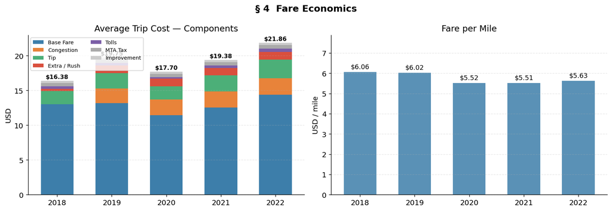

```python
yoy = duckdb.sql('''
    WITH base AS (
        SELECT
            pickup_year,
            AVG(fare_per_mile)                 AS fare_per_mile,
            AVG(total_amount)                  AS avg_total,
            AVG(fare_amount)                   AS avg_fare,
            AVG(congestion_surcharge)          AS avg_congestion,
            AVG(tip_amount)                    AS avg_tip,
            AVG(tolls_amount)                  AS avg_tolls,
            AVG(extra)                         AS avg_extra,
            AVG(mta_tax)                       AS avg_mta,
            AVG(improvement_surcharge)         AS avg_improvement
        FROM trips_fe
        WHERE pickup_year < 2023
        GROUP BY pickup_year
    )
    SELECT
        pickup_year,
        ROUND(fare_per_mile,   2) AS fare_per_mile,
        ROUND(avg_fare,        2) AS avg_fare,
        ROUND(avg_congestion,  2) AS avg_congestion,
        ROUND(avg_tip,         2) AS avg_tip,
        ROUND(avg_tolls,       2) AS avg_tolls,
        ROUND(avg_extra,       2) AS avg_extra,
        ROUND(avg_mta,         2) AS avg_mta,
        ROUND(avg_improvement, 2) AS avg_improvement,
        ROUND(avg_total,       2) AS avg_total
    FROM base
    ORDER BY pickup_year
''').pl()

display(yoy)

years    = yoy['pickup_year'].to_list()
arr_fare = yoy['avg_fare'].to_list()
arr_cong = yoy['avg_congestion'].to_list()
arr_tip  = yoy['avg_tip'].to_list()
arr_ext  = yoy['avg_extra'].to_list()
arr_toll = yoy['avg_tolls'].to_list()
arr_mta  = yoy['avg_mta'].to_list()
arr_imp  = yoy['avg_improvement'].to_list()
arr_fpm  = yoy['fare_per_mile'].to_list()

fig, axes = plt.subplots(1, 2, figsize=(13, 4.5))

# ── left: stacked cost components ──────────────────────────────────────────
ax = axes[0]
bottom = np.zeros(len(years))
components = [
    (arr_fare, 'Base Fare',    BLUE),
    (arr_cong, 'Congestion',   ORANGE),
    (arr_tip,  'Tip',          GREEN),
    (arr_ext,  'Extra / Rush', RED),
    (arr_toll, 'Tolls',        PURPLE),
    (arr_mta,  'MTA Tax',      GREY),
    (arr_imp,  'Improvement',  '#CCCCCC'),
]
for vals, lbl, col in components:
    ax.bar(years, vals, bottom=bottom, label=lbl, color=col, width=0.6)
    bottom += np.array(vals)
for y, tot in zip(years, bottom):
    ax.text(y, tot + 0.15, f'${tot:.2f}',
            ha='center', va='bottom', fontsize=9, fontweight='bold')
ax.set_title('Average Trip Cost — Components')
ax.set_ylabel('USD')
ax.set_xticks(years)
ax.legend(fontsize=8, loc='upper left', ncol=2)

# ── right: fare per mile ───────────────────────────────────────────────────
ax2 = axes[1]
bars = ax2.bar(years, arr_fpm, color=BLUE, alpha=0.85, width=0.6)
ax2.bar_label(bars, fmt='$%.2f', padding=3, fontsize=10)
ax2.set_title('Fare per Mile')
ax2.set_ylabel('USD / mile')
ax2.set_xticks(years)
ax2.set_ylim(0, max(arr_fpm) * 1.3)

plt.suptitle('§ 4  Fare Economics', fontsize=14, fontweight='bold')
plt.tight_layout()
plt.show()
```

## 5. Trip Shape — Distance, Duration, and Speed

**The 2020 signal is unmistakeable.** Average trip duration fell from 14.6 min to 11.7 min (−20%), and average speed jumped from 11.3 mph to 13.1 mph (+16%). These are not driven by shorter trips — median distance barely changed (1.64 mi in 2018 vs 1.69 mi in 2020). Empty streets simply accelerated every trip.

shape: (5, 6)

| pickup_year i64 | p25_dist f64 | med_dist f64 | p75_dist f64 | avg_dur f64 | avg_speed f64 |
| --- | --- | --- | --- | --- | --- |
| 2018 | 1.0 | 1.64 | 3.08 | 14.6 | 11.3 |
| 2019 | 1.0 | 1.65 | 3.08 | 14.6 | 11.4 |
| 2020 | 1.0 | 1.69 | 2.93 | 11.7 | 13.1 |
| 2021 | 1.09 | 1.78 | 3.1 | 13.4 | 12.4 |
| 2022 | 1.15 | 1.9 | 3.5 | 15.6 | 12.1 |

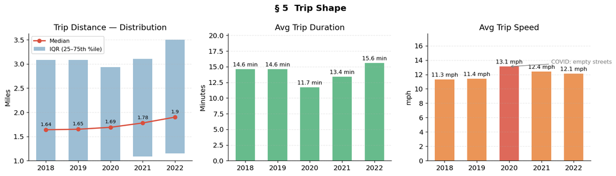

```python
dist_q = duckdb.sql('''
    SELECT
        pickup_year,
        ROUND(PERCENTILE_CONT(0.25) WITHIN GROUP (ORDER BY trip_distance), 2) AS p25_dist,
        ROUND(PERCENTILE_CONT(0.50) WITHIN GROUP (ORDER BY trip_distance), 2) AS med_dist,
        ROUND(PERCENTILE_CONT(0.75) WITHIN GROUP (ORDER BY trip_distance), 2) AS p75_dist,
        ROUND(AVG(duration_min), 1)  AS avg_dur,
        ROUND(AVG(speed_mph),    1)  AS avg_speed
    FROM trips_fe
    WHERE pickup_year < 2023
    GROUP BY pickup_year
    ORDER BY pickup_year
''').pl()

display(dist_q)

years = dist_q['pickup_year'].to_list()
p25   = dist_q['p25_dist'].to_list()
med   = dist_q['med_dist'].to_list()
p75   = dist_q['p75_dist'].to_list()
dur   = dist_q['avg_dur'].to_list()
spd   = dist_q['avg_speed'].to_list()

fig, axes = plt.subplots(1, 3, figsize=(14, 4))

# distance IQR + median
ax = axes[0]
iqr = [p75[i] - p25[i] for i in range(len(years))]
ax.bar(years, iqr, bottom=p25, color=BLUE, alpha=0.5, width=0.6, label='IQR (25–75th %ile)')
ax.plot(years, med, 'o-', color=RED, lw=2, ms=6, label='Median')
for y, m in zip(years, med):
    ax.text(y, m + 0.06, str(m), ha='center', va='bottom', fontsize=8)
ax.set_title('Trip Distance — Distribution')
ax.set_ylabel('Miles')
ax.set_xticks(years)
ax.legend(fontsize=9)

# avg duration
ax2 = axes[1]
bars2 = ax2.bar(years, dur, color=GREEN, alpha=0.85, width=0.6)
ax2.bar_label(bars2, fmt='%.1f min', padding=3, fontsize=9)
ax2.set_title('Avg Trip Duration')
ax2.set_ylabel('Minutes')
ax2.set_xticks(years)
ax2.set_ylim(0, max(dur) * 1.3)

# avg speed — highlight 2020
ax3 = axes[2]
bar_colors = [RED if y == 2020 else ORANGE for y in years]
bars3 = ax3.bar(years, spd, color=bar_colors, alpha=0.85, width=0.6)
ax3.bar_label(bars3, fmt='%.1f mph', padding=3, fontsize=9)
ax3.set_title('Avg Trip Speed')
ax3.set_ylabel('mph')
ax3.set_xticks(years)
ax3.set_ylim(0, max(spd) * 1.35)
idx = years.index(2020)
ax3.annotate('COVID: empty streets',
    xy=(2020, spd[idx]), xytext=(2021.3, spd[idx] + 0.4),
    arrowprops=dict(arrowstyle='->', color='grey'),
    fontsize=9, color='grey')

plt.suptitle('§ 5  Trip Shape', fontsize=14, fontweight='bold')
plt.tight_layout()
plt.show()
```

## 6. The 2020 COVID Shock

The heatmap below shows sampled trip count per month per year. Every 2018–2019 row is nearly uniform. In 2020, April and May are visibly lighter, confirming the COVID dip is preserved in the sampled data.

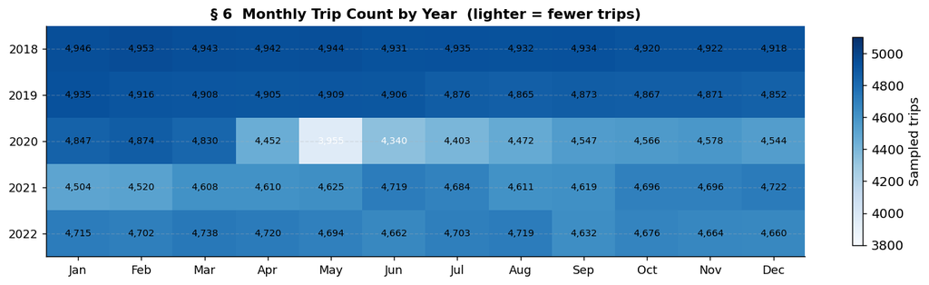

```python
monthly_q = duckdb.sql('''
    SELECT pickup_year, pickup_month, COUNT(*) AS trips
    FROM trips_fe
    WHERE pickup_year BETWEEN 2018 AND 2022
    GROUP BY pickup_year, pickup_month
    ORDER BY pickup_year, pickup_month
''').pl()

pivot = monthly_q.to_pandas().pivot(
    index='pickup_year', columns='pickup_month', values='trips'
)
month_labels = ['Jan','Feb','Mar','Apr','May','Jun',
                'Jul','Aug','Sep','Oct','Nov','Dec']
pivot.columns = month_labels

fig, ax = plt.subplots(figsize=(12, 3.5))
vmin, vmax = 3800, 5100
im = ax.imshow(pivot.values, aspect='auto', cmap='Blues', vmin=vmin, vmax=vmax)

ax.set_xticks(range(12))
ax.set_xticklabels(month_labels, fontsize=10)
ax.set_yticks(range(pivot.shape[0]))
ax.set_yticklabels(pivot.index.astype(str), fontsize=10)

for r in range(pivot.shape[0]):
    for c in range(pivot.shape[1]):
        v = int(pivot.values[r, c])
        brightness = (v - vmin) / (vmax - vmin)
        txt_color  = 'white' if brightness < 0.45 else 'black'
        ax.text(c, r, f'{v:,}', ha='center', va='center',
                fontsize=8, color=txt_color)

plt.colorbar(im, ax=ax, label='Sampled trips', shrink=0.9)
ax.set_title('§ 6  Monthly Trip Count by Year  (lighter = fewer trips)',
             fontsize=12, fontweight='bold')
plt.tight_layout()
plt.show()
```

## 7. Payment Type Evolution

| payment_label pickup_year | Card | Cash | Other |
| --- | --- | --- | --- |
| 2018 | 69.9 | 29.6 | 0.5 |
| 2019 | 72.6 | 26.9 | 0.5 |
| 2020 | 70.4 | 28.8 | 0.8 |
| 2021 | 76.9 | 22.7 | 0.5 |
| 2022 | 79.2 | 20.3 | 0.5 |

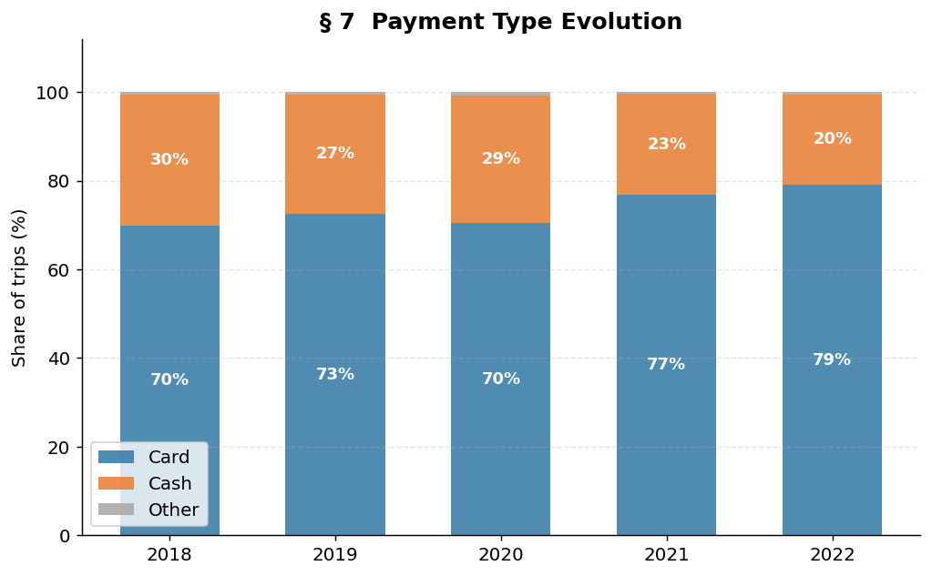

```python
pay_q = duckdb.sql('''
    WITH b AS (
        SELECT pickup_year, payment_label, COUNT(*) AS n
        FROM trips_fe WHERE pickup_year < 2023
        GROUP BY pickup_year, payment_label
    ),
    t AS (SELECT pickup_year, SUM(n) AS tot FROM b GROUP BY pickup_year)
    SELECT b.pickup_year, b.payment_label,
           ROUND(100.0 * b.n / t.tot, 1) AS pct
    FROM b JOIN t USING (pickup_year)
    ORDER BY b.pickup_year, b.payment_label
''').pl()

display(pay_q.to_pandas().pivot(
    index='pickup_year', columns='payment_label', values='pct'))

years  = sorted(pay_q['pickup_year'].unique().to_list())
labels = ['Card', 'Cash', 'Other']
colors = [BLUE, ORANGE, GREY]

data = {}
for lbl in labels:
    data[lbl] = [
        float(pay_q.filter(
            (pl.col('pickup_year') == y) & (pl.col('payment_label') == lbl)
        ).select('pct').to_series()[0])
        for y in years
    ]

fig, ax = plt.subplots(figsize=(8, 5))
bottom = np.zeros(len(years))
for lbl, col in zip(labels, colors):
    vals = np.array(data[lbl])
    ax.bar(years, vals, bottom=bottom, label=lbl, color=col, alpha=0.9, width=0.6)
    for y, v, b in zip(years, vals, bottom):
        if v > 3:
            ax.text(y, b + v / 2, f'{v:.0f}%',
                    ha='center', va='center', fontsize=10,
                    color='white', fontweight='bold')
    bottom += vals

ax.set_ylim(0, 112)
ax.set_ylabel('Share of trips (%)')
ax.set_xticks(years)
ax.set_yticks(range(0, 101, 20))
ax.legend(fontsize=11)
ax.set_title('§ 7  Payment Type Evolution', fontsize=14, fontweight='bold')
plt.tight_layout()
plt.show()
```

## 8. Tipping Behavior

Tip data is reliable only for **card trips** — cash tips are self-reported to the meter and overwhelmingly appear as $0. This section uses card-paying riders only.

**The shift is structural, not economic.** In 2018, nearly 49% of card trips tipped in the 20–25% range, consistent with a default in-app prompt of 20%. By 2022, the 25–30% and 30%+ buckets together account for 60% of card trips, while the 20–25% bucket collapsed to 19%. This mirrors the industry-wide shift to higher default tip presets that began around 2019–2020.

Average card tip: $2.70 (2018) → $3.44 (2022), tracking the higher default percentages and higher base fares.

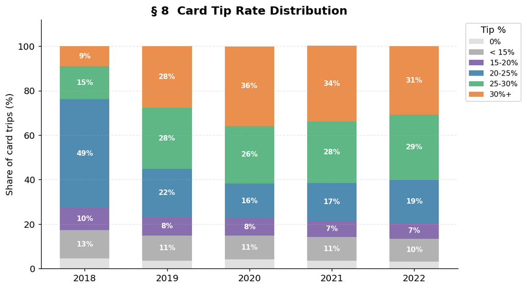

```python
tip_q = duckdb.sql('''
    WITH buckets AS (
        SELECT
            pickup_year,
            CASE
                WHEN tip_pct = 0       THEN '0%'
                WHEN tip_pct < 15      THEN '< 15%'
                WHEN tip_pct < 20      THEN '15-20%'
                WHEN tip_pct < 25      THEN '20-25%'
                WHEN tip_pct < 30      THEN '25-30%'
                ELSE                        '30%+'
            END AS bucket,
            COUNT(*) AS n
        FROM trips_fe
        WHERE pickup_year < 2023 AND payment_type = 1
        GROUP BY pickup_year, bucket
    ),
    tot AS (SELECT pickup_year, SUM(n) AS total FROM buckets GROUP BY pickup_year)
    SELECT
        b.pickup_year, b.bucket,
        ROUND(100.0 * b.n / t.total, 1) AS pct
    FROM buckets b JOIN tot t USING (pickup_year)
    ORDER BY b.pickup_year,
        CASE b.bucket
            WHEN '0%'    THEN 0 WHEN '< 15%' THEN 1
            WHEN '15-20%' THEN 2 WHEN '20-25%' THEN 3
            WHEN '25-30%' THEN 4 ELSE 5
        END
''').pl()

years   = sorted(tip_q['pickup_year'].unique().to_list())
buckets = ['0%', '< 15%', '15-20%', '20-25%', '25-30%', '30%+']
bcolors = ['#DDDDDD', '#AAAAAA', PURPLE, BLUE, GREEN, ORANGE]

data = {}
for bk in buckets:
    data[bk] = [
        float(tip_q.filter(
            (pl.col('pickup_year') == y) & (pl.col('bucket') == bk)
        ).select('pct').to_series()[0])
        if tip_q.filter(
            (pl.col('pickup_year') == y) & (pl.col('bucket') == bk)
        ).shape[0] > 0 else 0.0
        for y in years
    ]

fig, ax = plt.subplots(figsize=(9, 5))
bottom = np.zeros(len(years))
for bk, col in zip(buckets, bcolors):
    vals = np.array(data[bk])
    ax.bar(years, vals, bottom=bottom, label=bk, color=col, alpha=0.9, width=0.6)
    for y, v, b in zip(years, vals, bottom):
        if v > 5:
            ax.text(y, b + v / 2, f'{v:.0f}%',
                    ha='center', va='center', fontsize=8.5,
                    color='white', fontweight='bold')
    bottom += vals

ax.set_ylim(0, 112)
ax.set_ylabel('Share of card trips (%)')
ax.set_xticks(years)
ax.set_yticks(range(0, 101, 20))
ax.legend(fontsize=9, title='Tip %', bbox_to_anchor=(1.01, 1), loc='upper left')
ax.set_title('§ 8  Card Tip Rate Distribution', fontsize=14, fontweight='bold')
plt.tight_layout()
plt.show()
```

## 9. Airport vs. City Trips

Rate code 2 (JFK flat-rate) and rate code 3 (Newark) identify airport-bound Yellow Taxi trips. These are already a small minority of Yellow Taxi volume — ~2.4% in 2018 — because TNC platforms dominate airport ground transport.

Two caveats apply. First, the absolute trip count is small enough that sampling noise is a real concern — a different random draw from the same year could move this percentage meaningfully. Second, even at 4.0%, Yellow Taxi handles a fraction of total airport ground transport. This is a directional recovery signal, not evidence of a competitive resurgence against TNCs. A borough-level and route-level cut of the full TLC public dataset would be needed to size the opportunity reliably.

| trip_type pickup_year | Airport | Other | Standard |
| --- | --- | --- | --- |
| 2018 | 2.36 | 0.25 | 97.39 |
| 2019 | 2.74 | 0.32 | 96.94 |
| 2020 | 1.25 | 0.25 | 98.50 |
| 2021 | 2.28 | 0.26 | 97.46 |
| 2022 | 4.05 | 0.39 | 95.56 |

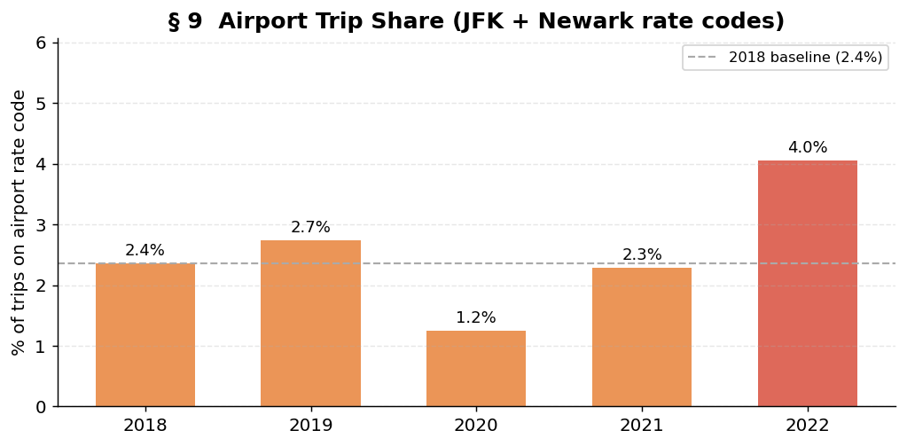

```python
airport_q = duckdb.sql('''
    WITH b AS (
        SELECT pickup_year, trip_type, COUNT(*) AS n
        FROM trips_fe WHERE pickup_year < 2023
        GROUP BY pickup_year, trip_type
    ),
    t AS (SELECT pickup_year, SUM(n) AS tot FROM b GROUP BY pickup_year)
    SELECT b.pickup_year, b.trip_type,
           ROUND(100.0 * b.n / t.tot, 2) AS pct
    FROM b JOIN t USING (pickup_year)
    ORDER BY b.pickup_year, b.trip_type
''').pl()

display(airport_q.to_pandas().pivot(
    index='pickup_year', columns='trip_type', values='pct'))

years = sorted(airport_q['pickup_year'].unique().to_list())
airport_pct = [
    float(airport_q.filter(
        (pl.col('pickup_year') == y) & (pl.col('trip_type') == 'Airport')
    ).select('pct').to_series()[0])
    if airport_q.filter(
        (pl.col('pickup_year') == y) & (pl.col('trip_type') == 'Airport')
    ).shape[0] > 0 else 0.0
    for y in years
]

bar_colors = [RED if p == max(airport_pct) else ORANGE for p in airport_pct]
fig, ax = plt.subplots(figsize=(8, 4))
bars = ax.bar(years, airport_pct, color=bar_colors, alpha=0.85, width=0.6)
ax.bar_label(bars, fmt='%.1f%%', padding=3, fontsize=10)
ax.set_ylim(0, max(airport_pct) * 1.5)
ax.set_ylabel('% of trips on airport rate code')
ax.set_xticks(years)
ax.axhline(airport_pct[0], color=GREY, linestyle='--', lw=1.2,
           label=f'2018 baseline ({airport_pct[0]:.1f}%)')
ax.legend(fontsize=9)
ax.set_title('§ 9  Airport Trip Share (JFK + Newark rate codes)',
             fontsize=14, fontweight='bold')
plt.tight_layout()
plt.show()
```

## 10. Congestion Surcharge Adoption

The data confirms near-instant adoption:

shape: (5, 4)

| pickup_year i64 | trips i64 | with_congestion i64 | cong_pct f64 |
| --- | --- | --- | --- |
| 2018 | 59220 | 0 | 0.0 |
| 2019 | 58683 | 49384 | 84.2 |
| 2020 | 54408 | 49180 | 90.4 |
| 2021 | 55614 | 51824 | 93.2 |
| 2022 | 56285 | 52619 | 93.5 |

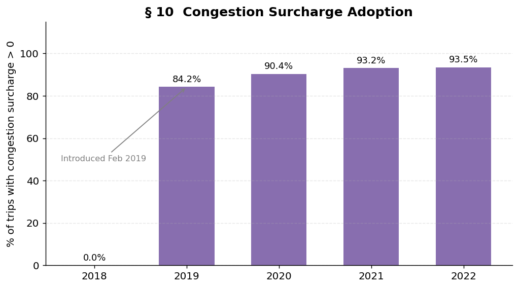

```python
cong_q = duckdb.sql('''
    SELECT
        pickup_year,
        COUNT(*)                                                        AS trips,
        COUNT(*) FILTER (WHERE has_congestion)                          AS with_congestion,
        ROUND(100.0 * COUNT(*) FILTER (WHERE has_congestion) / COUNT(*), 1) AS cong_pct
    FROM trips_fe
    WHERE pickup_year < 2023
    GROUP BY pickup_year
    ORDER BY pickup_year
''').pl()

display(cong_q)

years    = cong_q['pickup_year'].to_list()
cong_pct = cong_q['cong_pct'].to_list()

bar_colors = ['#DDDDDD' if c == 0 else PURPLE for c in cong_pct]

fig, ax = plt.subplots(figsize=(8, 4.5))
bars = ax.bar(years, cong_pct, color=bar_colors, alpha=0.9, width=0.6)
ax.bar_label(bars, fmt='%.1f%%', padding=3, fontsize=10)
ax.set_ylim(0, 115)
ax.set_ylabel('% of trips with congestion surcharge > 0')
ax.set_xticks(years)

ax.annotate('Introduced Feb 2019',
    xy=(2019, cong_pct[years.index(2019)]),
    xytext=(2018.1, cong_pct[years.index(2019)] - 35),
    arrowprops=dict(arrowstyle='->', color='grey'),
    fontsize=9, color='grey', ha='center')

ax.set_title('§ 10  Congestion Surcharge Adoption',
             fontsize=14, fontweight='bold')
plt.tight_layout()
plt.show()
```

## 11. Congestion Surcharge — The Policy Tax Hiding in Your Total

§4 showed total cost rose ~$4.89 from 2018 to 2022. This section asks: **where exactly did that money go?**

The answer: the 2019 congestion surcharge alone accounts for **$2.34** of the $4.89 increase — 48%. The *entire* rise in base fare over the same five years adds only $1.38 (28%). Put differently, a rider comparing their 2018 and 2022 receipts would think fares got more expensive, when really a new line-item — invisible to them as a separate charge — drove nearly half the increase.

shape: (1, 9)

| d_fare f64 | d_cong f64 | d_tip f64 | d_extra f64 | d_mta f64 | d_imp f64 | d_toll f64 | d_total f64 | base_2018 f64 |
| --- | --- | --- | --- | --- | --- | --- | --- | --- |
| 1.38 | 2.34 | 0.83 | 0.73 | -0.0 | 0.02 | 0.18 | 4.89 | 16.387618 |

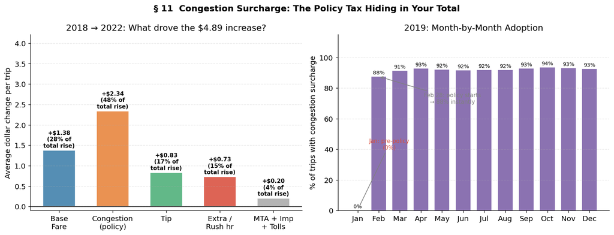

```python
# ── Delta decomposition: 2018 → 2022 ────────────────────────────────────
delta_q = duckdb.sql('''
    WITH y AS (
        SELECT pickup_year,
            AVG(fare_amount)          AS a_fare,
            AVG(congestion_surcharge) AS a_cong,
            AVG(tip_amount)           AS a_tip,
            AVG(extra)                AS a_extra,
            AVG(mta_tax)              AS a_mta,
            AVG(improvement_surcharge) AS a_imp,
            AVG(tolls_amount)         AS a_toll,
            AVG(total_amount)         AS a_total
        FROM trips_fe WHERE pickup_year IN (2018, 2022)
        GROUP BY pickup_year
    )
    SELECT
        ROUND(MAX(CASE WHEN pickup_year=2022 THEN a_fare  END)
            - MAX(CASE WHEN pickup_year=2018 THEN a_fare  END), 2) AS d_fare,
        ROUND(MAX(CASE WHEN pickup_year=2022 THEN a_cong  END)
            - MAX(CASE WHEN pickup_year=2018 THEN a_cong  END), 2) AS d_cong,
        ROUND(MAX(CASE WHEN pickup_year=2022 THEN a_tip   END)
            - MAX(CASE WHEN pickup_year=2018 THEN a_tip   END), 2) AS d_tip,
        ROUND(MAX(CASE WHEN pickup_year=2022 THEN a_extra END)
            - MAX(CASE WHEN pickup_year=2018 THEN a_extra END), 2) AS d_extra,
        ROUND(MAX(CASE WHEN pickup_year=2022 THEN a_mta   END)
            - MAX(CASE WHEN pickup_year=2018 THEN a_mta   END), 2) AS d_mta,
        ROUND(MAX(CASE WHEN pickup_year=2022 THEN a_imp   END)
            - MAX(CASE WHEN pickup_year=2018 THEN a_imp   END), 2) AS d_imp,
        ROUND(MAX(CASE WHEN pickup_year=2022 THEN a_toll  END)
            - MAX(CASE WHEN pickup_year=2018 THEN a_toll  END), 2) AS d_toll,
        ROUND(MAX(CASE WHEN pickup_year=2022 THEN a_total END)
            - MAX(CASE WHEN pickup_year=2018 THEN a_total END), 2) AS d_total,
        MAX(CASE WHEN pickup_year=2018 THEN a_total END)           AS base_2018
    FROM y
''').pl()

display(delta_q)

# ── 2019 monthly adoption ────────────────────────────────────────────────────
cong_2019 = duckdb.sql('''
    SELECT pickup_month,
        ROUND(100.0 * COUNT(*) FILTER (WHERE has_congestion) / COUNT(*), 1) AS pct_with_cong,
        ROUND(AVG(congestion_surcharge), 2)                                  AS avg_surcharge
    FROM trips_fe WHERE pickup_year = 2019
    GROUP BY pickup_month
    ORDER BY pickup_month
''').pl()

# ── Build waterfall / delta bar chart ────────────────────────────────────────
row      = delta_q.row(0, named=True)
base     = float(row['base_2018'])
d_fare   = float(row['d_fare'])
d_cong   = float(row['d_cong'])
d_tip    = float(row['d_tip'])
d_extra  = float(row['d_extra'])
d_other  = float(row['d_mta']) + float(row['d_imp']) + float(row['d_toll'])
d_total  = float(row['d_total'])

components = [
    ('Base\nFare',   d_fare,  BLUE),
    ('Congestion\n(policy)', d_cong,  ORANGE),
    ('Tip',          d_tip,   GREEN),
    ('Extra /\nRush hr',  d_extra, RED),
    ('MTA + Imp\n+ Tolls', d_other, GREY),
]

months     = cong_2019['pickup_month'].to_list()
pct_cong   = cong_2019['pct_with_cong'].to_list()
month_lbl  = ['Jan','Feb','Mar','Apr','May','Jun','Jul','Aug','Sep','Oct','Nov','Dec']

fig, axes = plt.subplots(1, 2, figsize=(13, 5))

# ── left: delta bar chart with % annotation ───────────────────────────────
ax = axes[0]
labels = [c[0] for c in components]
values = [c[1] for c in components]
colors = [c[2] for c in components]
bars = ax.bar(labels, values, color=colors, alpha=0.88, width=0.6, edgecolor='white')
for bar, v in zip(bars, values):
    pct = 100 * v / d_total
    ax.text(bar.get_x() + bar.get_width()/2, v + 0.04,
            f'+${v:.2f}\n({pct:.0f}% of\ntotal rise)',
            ha='center', va='bottom', fontsize=8.5, fontweight='bold')
ax.set_title('2018 → 2022: What drove the $4.89 increase?')
ax.set_ylabel('Average dollar change per trip')
ax.axhline(0, color='black', lw=0.8)
ax.set_ylim(-0.1, d_cong * 1.8)

# ── right: 2019 monthly congestion adoption ───────────────────────────────
ax2 = axes[1]
bar_clr = [RED if m == 1 else PURPLE for m in months]
bars2 = ax2.bar([month_lbl[m-1] for m in months], pct_cong,
                color=bar_clr, alpha=0.88, width=0.7)
ax2.bar_label(bars2, fmt='%.0f%%', padding=2, fontsize=8)
ax2.set_ylim(0, 115)
ax2.set_ylabel('% of trips with congestion surcharge')
ax2.set_title('2019: Month-by-Month Adoption')
ax2.annotate('Jan: pre-policy\n(0%)',
    xy=(0, 0.5), xytext=(1.5, 40),
    arrowprops=dict(arrowstyle='->', color='grey'),
    fontsize=8.5, color=RED, ha='center')
ax2.annotate('Feb 28: policy starts\n→ 88% instantly',
    xy=(1, pct_cong[1]), xytext=(4.5, 70),
    arrowprops=dict(arrowstyle='->', color='grey'),
    fontsize=8.5, color='grey', ha='center')

plt.suptitle('§ 11  Congestion Surcharge: The Policy Tax Hiding in Your Total',
             fontsize=13, fontweight='bold')
plt.tight_layout()
plt.show()
```

## 12. Tip Prompt Engineering — How Defaults Reshaped Rider Behavior

The §8 bucket chart showed that tip rates on card trips climbed from ~22% to ~27% median. This section digs into the *mechanism*: in-app prompt architecture.

When taxi apps display a three-button tip prompt, riders are strongly anchored to the middle option. Changing those defaults from [15 / 20 / 25%] to [20 / 25 / 30%] — or adding a 30% button — does not require riders to become more generous. It requires only that they continue clicking the path of least resistance.

**Two charts reveal this:**

shape: (5, 5)

| pickup_year i64 | mean_tip_pct f64 | median_tip_pct f64 | pct_zero_tip f64 | avg_tip_dollars f64 |
| --- | --- | --- | --- | --- |
| 2018 | 22.3 | 22.1 | 4.5 | 2.7 |
| 2019 | 26.1 | 26.0 | 3.5 | 3.06 |
| 2020 | 28.0 | 27.3 | 4.1 | 2.75 |
| 2021 | 27.6 | 27.2 | 3.6 | 3.0 |
| 2022 | 27.2 | 26.6 | 3.2 | 3.44 |

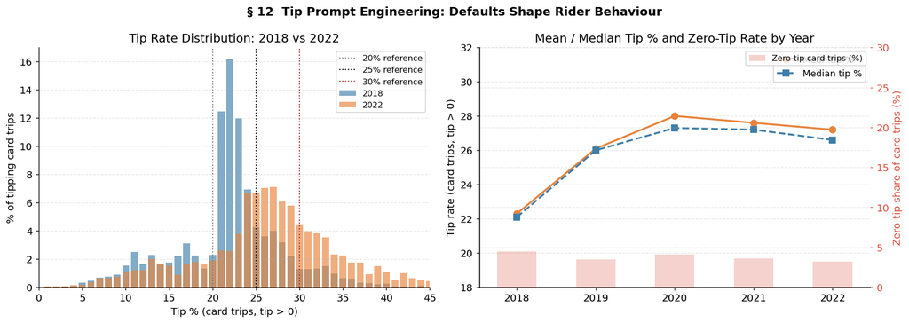

```python
# ── Histogram distribution of tip_pct (card trips, tip > 0) ────────────────
hist_q = duckdb.sql('''
    WITH c AS (
        SELECT pickup_year, tip_pct
        FROM trips_fe
        WHERE pickup_year IN (2018, 2022) AND payment_type = 1 AND tip_pct > 0
    )
    SELECT pickup_year, ROUND(tip_pct) AS tip_bin, COUNT(*) AS n
    FROM c
    WHERE tip_pct BETWEEN 1 AND 50
    GROUP BY pickup_year, tip_bin
    ORDER BY pickup_year, tip_bin
''').pl()

# ── Year-by-year tip summary ──────────────────────────────────────────────────
tip_yoy = duckdb.sql('''
    SELECT
        pickup_year,
        ROUND(AVG(tip_pct) FILTER (WHERE payment_type=1 AND tip_pct>0), 1)       AS mean_tip_pct,
        ROUND(PERCENTILE_CONT(0.5) WITHIN GROUP (ORDER BY tip_pct)
              FILTER (WHERE payment_type=1 AND tip_pct>0), 1)                     AS median_tip_pct,
        ROUND(100.0 * COUNT(*) FILTER (WHERE payment_type=1 AND tip_pct=0)
            / COUNT(*) FILTER (WHERE payment_type=1), 1)                          AS pct_zero_tip,
        ROUND(AVG(tip_amount) FILTER (WHERE payment_type=1), 2)                   AS avg_tip_dollars
    FROM trips_fe
    WHERE pickup_year < 2023
    GROUP BY pickup_year
    ORDER BY pickup_year
''').pl()

display(tip_yoy)

years = tip_yoy['pickup_year'].to_list()

# ── Build charts ──────────────────────────────────────────────────────────────
fig, axes = plt.subplots(1, 2, figsize=(14, 5))

# left: overlaid histogram 2018 vs 2022
ax = axes[0]
for yr, col, alpha, lbl in [(2018, BLUE, 0.65, '2018'), (2022, ORANGE, 0.65, '2022')]:
    sub = hist_q.filter(pl.col('pickup_year') == yr)
    bins = sub['tip_bin'].to_list()
    ns   = sub['n'].to_list()
    total = sum(ns)
    pcts  = [100 * v / total for v in ns]
    ax.bar(bins, pcts, width=0.8, color=col, alpha=alpha, label=lbl)
ax.set_xlim(0, 45)
ax.set_xlabel('Tip % (card trips, tip > 0)')
ax.set_ylabel('% of tipping card trips')
ax.axvline(20, color='grey', linestyle=':', lw=1.2, label='20% reference')
ax.axvline(25, color='black', linestyle=':', lw=1.2, label='25% reference')
ax.axvline(30, color='brown', linestyle=':', lw=1.2, label='30% reference')
ax.legend(fontsize=9)
ax.set_title('Tip Rate Distribution: 2018 vs 2022')

# right: mean + median trend lines
ax2 = axes[1]
ax2.plot(years, tip_yoy['mean_tip_pct'].to_list(),
         'o-', color=ORANGE, lw=2, ms=7, label='Mean tip %')
ax2.plot(years, tip_yoy['median_tip_pct'].to_list(),
         's--', color=BLUE, lw=2, ms=7, label='Median tip %')
ax2.set_ylabel('Tip rate (card trips, tip > 0)')
ax2.set_xticks(years)
ax2.legend(fontsize=10)

ax2b = ax2.twinx()
ax2b.bar(years, tip_yoy['pct_zero_tip'].to_list(),
         alpha=0.25, color=RED, width=0.5, label='Zero-tip card trips (%)')
ax2b.set_ylabel('Zero-tip share of card trips (%)', color=RED)
ax2b.tick_params(axis='y', colors=RED)
ax2b.set_ylim(0, 30)
ax2b.legend(loc='upper right', fontsize=9)

ax2.set_title('Mean / Median Tip % and Zero-Tip Rate by Year')
ax2.set_ylim(18, 32)

plt.suptitle('§ 12  Tip Prompt Engineering: Defaults Shape Rider Behaviour',
             fontsize=13, fontweight='bold')
plt.tight_layout()
plt.show()
```

## 13. The 2020 Speed Anomaly — Rush Hour Won the Race

§5 showed that average trip speed jumped from 11.3 mph to 13.1 mph in 2020. Two competing explanations exist:

1. **Trip-type shift**: trips in 2020 were shorter / to less congested areas, so naturally faster
2. **Congestion collapse**: roads emptied, making *every* trip faster regardless of route

The data strongly favours explanation 2. This section shows:

**Speed by distance bin:** Controlling for trip distance, 2020 is faster across *every* distance bucket (< 1 mi, 1–2 mi, 2–3 mi, 3–5 mi, 5+ mi). The effect is not confined to short or long trips; it is structural.

shape: (15, 4)

| pickup_year i64 | dist_bin str | avg_speed f64 | trips i64 |
| --- | --- | --- | --- |
| 2018 | "< 1 mi" | 8.7 | 14748 |
| 2018 | "1-2 mi" | 9.3 | 19916 |
| 2018 | "2-3 mi" | 10.5 | 9175 |
| 2018 | "3-5 mi" | 12.5 | 6758 |
| 2018 | "5+ mi" | 20.3 | 8623 |
| … | … | … | … |
| 2022 | "< 1 mi" | 8.8 | 10480 |
| 2022 | "1-2 mi" | 9.6 | 18913 |
| 2022 | "2-3 mi" | 10.6 | 9963 |
| 2022 | "3-5 mi" | 12.5 | 7301 |
| 2022 | "5+ mi" | 21.6 | 9628 |

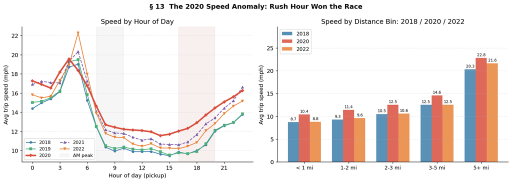

```python
# ── Speed by hour of day, all years ──────────────────────────────────────────
speed_hour = duckdb.sql('''
    SELECT pickup_year, pickup_hour,
           ROUND(AVG(speed_mph), 2) AS avg_speed,
           COUNT(*)                 AS trips
    FROM trips_fe
    WHERE pickup_year BETWEEN 2018 AND 2022
    GROUP BY pickup_year, pickup_hour
    ORDER BY pickup_year, pickup_hour
''').pl()

# ── Speed by distance bin, all years ─────────────────────────────────────────
speed_dist = duckdb.sql('''
    WITH binned AS (
        SELECT pickup_year,
            CASE
                WHEN trip_distance <  1 THEN '< 1 mi'
                WHEN trip_distance <  2 THEN '1-2 mi'
                WHEN trip_distance <  3 THEN '2-3 mi'
                WHEN trip_distance <  5 THEN '3-5 mi'
                ELSE                         '5+ mi'
            END AS dist_bin,
            speed_mph
        FROM trips_fe WHERE pickup_year < 2023
    )
    SELECT pickup_year, dist_bin,
           ROUND(AVG(speed_mph), 1) AS avg_speed,
           COUNT(*)                 AS trips
    FROM binned
    GROUP BY pickup_year, dist_bin
    ORDER BY pickup_year,
        CASE dist_bin
            WHEN '< 1 mi' THEN 0 WHEN '1-2 mi' THEN 1 WHEN '2-3 mi' THEN 2
            WHEN '3-5 mi' THEN 3 ELSE 4
        END
''').pl()

display(speed_dist.filter(pl.col('pickup_year').is_in([2018, 2020, 2022])))

# ── Build charts ──────────────────────────────────────────────────────────────
all_years  = [2018, 2019, 2020, 2021, 2022]
year_style = {
    2018: (BLUE,   '-',  1.5, 'o'),
    2019: (GREEN,  '-',  1.5, 's'),
    2020: (RED,    '-',  3.0, 'D'),   # highlighted
    2021: (PURPLE, '--', 1.5, '^'),
    2022: (ORANGE, '-',  1.5, 'v'),
}

fig, axes = plt.subplots(1, 2, figsize=(14, 5))

# ── left: speed by hour ───────────────────────────────────────────────────────
ax = axes[0]
for yr in all_years:
    sub  = speed_hour.filter(pl.col('pickup_year') == yr)
    hrs  = sub['pickup_hour'].to_list()
    spds = sub['avg_speed'].to_list()
    col, ls, lw, mk = year_style[yr]
    ax.plot(hrs, spds, linestyle=ls, lw=lw, color=col,
            marker=mk, ms=4, label=str(yr),
            zorder=5 if yr == 2020 else 2)
ax.set_xlabel('Hour of day (pickup)')
ax.set_ylabel('Avg trip speed (mph)')
ax.set_xticks(range(0, 24, 3))
ax.axvspan(7, 10, alpha=0.07, color='grey', label='AM peak')
ax.axvspan(16, 20, alpha=0.07, color='brown')
ax.set_title('Speed by Hour of Day')
ax.legend(fontsize=9, ncol=2)

# ── right: speed by distance bin (2018 / 2020 / 2022) ────────────────────────
ax2 = axes[1]
plot_years  = [2018, 2020, 2022]
dist_bins   = ['< 1 mi', '1-2 mi', '2-3 mi', '3-5 mi', '5+ mi']
x_pos       = range(len(dist_bins))
bar_w       = 0.25
offsets     = [-bar_w, 0, bar_w]

for yr, off in zip(plot_years, offsets):
    sub    = speed_dist.filter(pl.col('pickup_year') == yr)
    speeds = []
    for db in dist_bins:
        row = sub.filter(pl.col('dist_bin') == db)
        speeds.append(float(row['avg_speed'][0]) if row.shape[0] > 0 else 0.0)
    col = year_style[yr][0]
    bars = ax2.bar([x + off for x in x_pos], speeds,
                   width=bar_w, color=col, alpha=0.85, label=str(yr))
    ax2.bar_label(bars, fmt='%.1f', padding=2, fontsize=7.5)

ax2.set_xticks(list(x_pos))
ax2.set_xticklabels(dist_bins, fontsize=10)
ax2.set_ylabel('Avg trip speed (mph)')
ax2.set_title('Speed by Distance Bin: 2018 / 2020 / 2022')
ax2.legend(fontsize=10)
ax2.set_ylim(0, max(
    [float(speed_dist.filter((pl.col('pickup_year').is_in(plot_years)) & (pl.col('dist_bin') == db))['avg_speed'].max())
     for db in dist_bins]
) * 1.3)

plt.suptitle('§ 13  The 2020 Speed Anomaly: Rush Hour Won the Race',
             fontsize=13, fontweight='bold')
plt.tight_layout()
plt.show()
```